# Prueba de G y tablas de contingencia

Jordan Golubov y José Arévalo

2026-04-14

```r
library(ggplot2)
```

Las tablas de contingencia y las pruebas de bondad de ajuste son de las pruebas más útiles y sencillas en biología. Las características de ambas pruebas se basan en frecuencias o conteos de uno o más factores y la dependencia de una a otra. Hay dos formas principales por las que usamos la prueba de $\chi^{2}$:

- Tabla de contingencia. Independencia entre dos variables categóricas de una población, por ejemplo si el número de casos positivos y negativos para el coronavirus COVID-19 tienen alguna relación con el género de los pacientes.
- Prueba de G. Cuando nos interesa investigar si en las diferentes poblaciones estudiadas los valores o categorías de cada una de las manifestaciones se presentan en la misma proporción o en proporciones a partir de un valor teórico. Por ejemplo, si podemos esperar diferentes proporciones sexuales en una población de la 1:1 teórica.

Esto quiere decir que si lo que queremos probar es por ejemplo que las frecuencias de individuos dentro de cada edad es diferente entre dos poblaciones, o si hay cierta asociación entre el daño asociado a dos (o más) especies diferentes de insecto y la preferencia de dos (o más) especies de planta.

## Requisitos

- Muestras representativas de cada población
- Observaciones independientes
- Mediciones efectuadas en escala nominal u ordinal
- La clasificación de los individuos debe de ser exhuastiva y mutuamente excluyente

### Tipos de hipótesis

- En estudios descriptivos la hipótesis de nulidad plantea que las variables categóricas no se encuentran asociadas, por lo que la probabilidad de pertenecer a una categoría es independiente de las categorías de la otra variable
- En estudios comparativos la hipótesis de nulidad postula que no existen diferencias en las proporciones poblacionales de cada una de las categorías.

## Ejemplo 1

Tenemos un dado y queremos saber si esta cargado. Lo tiramos 100 veces y nos salen los siguientes resultados. En este caso los esperados básicamente son los que esparíamos si el dado fuera justo.

```
##   Observado Esperado
## 1        18    16.66
## 2        17    16.66
## 3        16    16.66
## 4        13    16.66
## 5        20    16.66
## 6        16    16.66
```

```r
knitr::kable(dados, caption = 'Dados tirados')
```

Dados tirados

| Observado | Esperado |
| --- | --- |
| 18 | 16.66 |
| 17 | 16.66 |
| 16 | 16.66 |
| 13 | 16.66 |
| 20 | 16.66 |
| 16 | 16.66 |

### Ejemplo 2

Queremos saber si el tamaño de la semilla y su forma de dispersión son independientes

```r
dispersion <- matrix(c(6,36,25,21),ncol=2)
rownames(dispersion) <- c('Grande','Chica')
colnames(dispersion) <- c('Hormiga','Vetebrado')
dispersion
```

```
##        Hormiga Vetebrado
## Grande       6        25
## Chica       36        21
```

### Ejemplo 3

Queremos saber si la causa de mortalidad de árboles es diferente en tres sitios de muestreo

```r
Tipos_de_mortalidad <- matrix(c(44,76,32,67,78,85,89,66,34),ncol=3)
rownames(Tipos_de_mortalidad) <- c('Bajo','Medio','Alto')
colnames(Tipos_de_mortalidad) <- c('Barrenador','Seco','Hongo')
Tipos_de_mortalidad
```

```
##       Barrenador Seco Hongo
## Bajo          44   67    89
## Medio         76   78    66
## Alto          32   85    34
```

## Graficar primero

En TODOS los análisis que se quieran hacer, es necesario tener una idea de lo que podemos esperar. Esto no da una idea de lo que podemos esperar de los análisis y detectar errores que podamos tener.

Podemos usar el paquete básico para graficar.

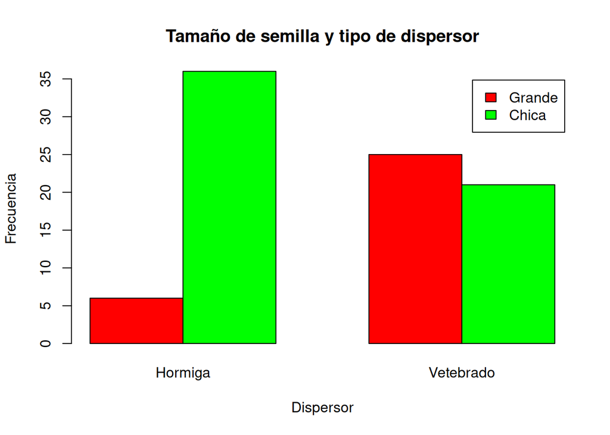

```r
barplot(dispersion,
        beside = TRUE,
        main = "Tamaño de semilla y tipo de dispersor",
        col = c("red", "green"),
        legend.text = rownames(dispersion),xlab = "Dispersor",ylab = "Frecuencia")
```

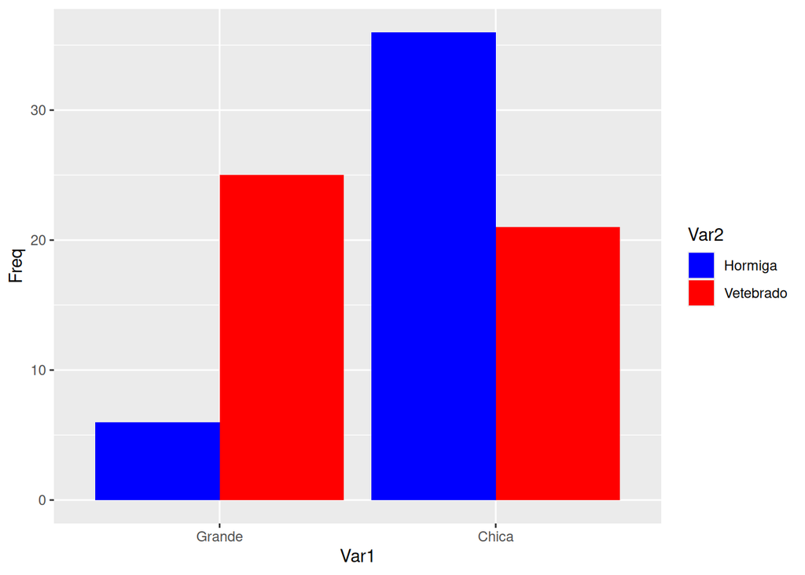

```r
dispersion.df <- as.data.frame(as.table(dispersion))
ggplot(dispersion.df,aes(x=Var1, y= Freq, fill=Var2))+
        geom_bar(stat= 'identity', position = 'dodge')+
        scale_fill_manual(values=c('blue','red'))
```

Usando los gráficos de R base

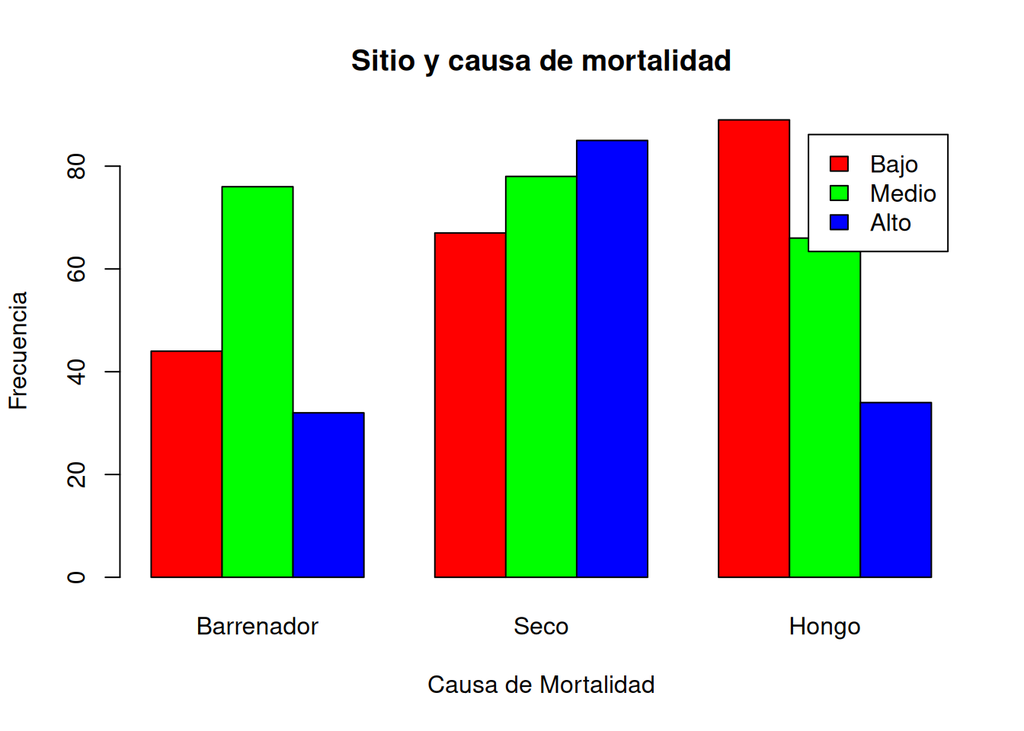

```r
barplot(Tipos_de_mortalidad,
        beside = TRUE,
        main = "Sitio y causa de mortalidad",
        col = c("red", "green","blue"),
        legend.text = rownames(Tipos_de_mortalidad),xlab = "Causa de Mortalidad",ylab = "Frecuencia")
```

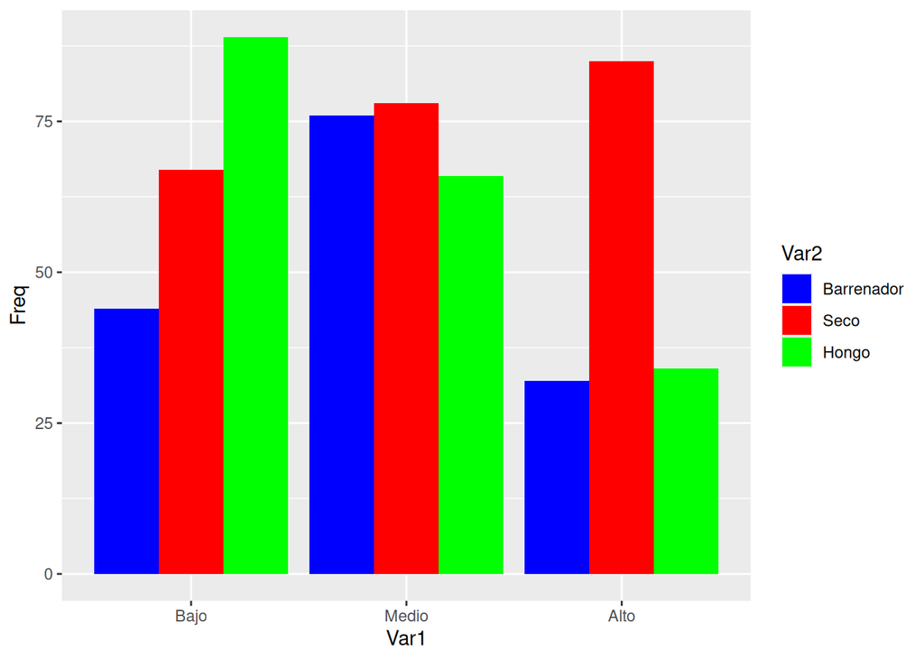

```r
mortalidad.df <- as.data.frame(as.table(Tipos_de_mortalidad))
ggplot(mortalidad.df,aes(x=Var1, y= Freq, fill=Var2))+
        geom_bar(stat= 'identity', position = 'dodge')+
        scale_fill_manual(values=c('blue','red','green'))
```

## Expresión matemática

$\chi^{2}= \sum{}{\frac{(Frecuencia \,de \,Observados - Frecuencia \, de \, Esperados)^{2}}{Frecuencia \, de \, Esperados}}$

Para sacar los esperados

$Esperados = \frac{Total \, del\, renglon \times Total \, de\, la \, columna}{Gran \, Total}$

Queremos saber si el tamaño de la semilla y su forma de dispersión son independientes

```r
dispersion.totales <- matrix(c(6,36,42,25,21,46,31,57,88),ncol=3)
rownames(dispersion.totales) <- c('Grande','Chica','Totales')
colnames(dispersion.totales) <- c('Hormiga','Vetebrado','Totales')
dispersion.totales
```

```
##         Hormiga Vetebrado Totales
## Grande        6        25      31
## Chica        36        21      57
## Totales      42        46      88
```

```r
dispersion.esperados <- matrix(c(14.79,16.20,27.20,29.79),ncol=2)
rownames(dispersion.esperados) <- c('Esperados Grande','Esperados Chica')
colnames(dispersion.esperados) <- c('Esperados Hormiga','Esperados Vetebrado')
dispersion.esperados
```

[output not shown]

Aplicamos la equation $\chi^{2}$

```r
dispersion.ji <- matrix(c(5.22,2.84,4.77,2.59),ncol=2)
rownames(dispersion.ji) <- c('Marginal Grande','Marginal Chica')
colnames(dispersion.ji) <- c('Marginal Hormiga','Marginal Vetebrado')
dispersion.ji
```

```
##                 Marginal Hormiga Marginal Vetebrado
## Marginal Grande             5.22               4.77
## Marginal Chica              2.84               2.59
```

### Los grados de libertad

Los grados de libertad se calculan como:

$grados \ de \ libertad = columnas -1 \times renglones -1$

en este caso la ecuación $gl = (2-1) \times (2-1)$

### La Hipótesis

La prueba de hipótesis es simplemente la comparación del valor de $\chi^{2}$ calculada con la de tablas con los grados de libertad calculados, y como siempre si el valor es mayor al de tablas se rechaza la hipótesis nula

### Ejemplo de los dados

Tenemos un dado y queremos saber si esta cargado. Lo tiramos 100 veces y nos salen los siguientes resultados. En este caso los esperados básicamente son los que esparíamos si el dado fuera justo.

Aplicando la fórmula de $\chi^{2}$ tenemos que

$$\chi^{2} = 0.1066 + 0.0066 +
0.0266 + 0.8066 + 0.6666 + 0.02666 = 1.64$$

En este caso los grados de libertad son 5.

### Regla de decisión

```
    En este caso tambien aceptamos la hipótesis nula que nos dice que el dado en realidad no esta cargado.
```

### Si lo hacemos en R con los dados

```r
dados.matriz <- as.matrix(dados[,1])
dados.matriz
```

```
##      [,1]
## [1,]   18
## [2,]   17
## [3,]   16
## [4,]   13
## [5,]   20
## [6,]   16
```

```r
prueba.dados <- chisq.test(dados.matriz)
prueba.dados
```

```
##
##  Chi-squared test for given probabilities
##
## data:  dados.matriz
## X-squared = 1.64, df = 5, p-value = 0.8964
```

### Para el caso de las síndromes de dispersión y el tamaño de la semilla en R resulta lo siguiente:

```r
chi.dispersion <- chisq.test(dispersion)
chi.dispersion
```

```
##
##  Pearson's Chi-squared test with Yates' continuity correction
##
## data:  dispersion
## X-squared = 13.737, df = 1, p-value = 0.0002103
```

```r
chi.dispersion$expected
```

```
##         Hormiga Vetebrado
## Grande 14.79545  16.20455
## Chica  27.20455  29.79545
```

```r
chi.dispersion$stdres
```

```
##         Hormiga Vetebrado
## Grande -3.92971   3.92971
## Chica   3.92971  -3.92971
```

La interpretación de los residuales es la siguiente. Ya que sabemos que hay una relación entre la dispersion y el dispersor, entonces podemos saber cùal de las celdas está contribuyendo al valor de la ji cuadrada. Acu´ñerdense que el cálculo de la ji cuadrada es una suma de cada celda. Entonces los residuales estandarizados lo que nos dicen es la contribución de cada celda a la ji cuadrada global y se prueba con básicamente una prueba de t. Sin irnos a los detalles la interpretación es que si el valor de la celda es mayor o menor a $|1.96|$ entonces contribuye de manera significativa a la ji cuadrada global, es decir esa combinación es significativa. El signo del valor nos dice si es más o menos de lo que esperaríamos si estas variables fueran independientes

Para el ejemplo de los tipo de mortalidad tenemos

```r
chi.mortalidad <- chisq.test(Tipos_de_mortalidad)
chi.mortalidad$residuals
```

```
##       Barrenador      Seco      Hongo
## Bajo   -1.266339 -1.510818  2.8022938
## Medio   2.278420 -1.127775 -0.7991635
## Alto   -1.292759  3.100030 -2.2604528
```

Para la interpretación de los residuales debes de tomar en cuenta por un lado que el valor de la celda sea $|1.96|$ y el signo de la celda